# House Price Prediction

Lohit Marla

2023-10-28

In this analysis focused on house price prediction, our objective is to forecast house prices through the development of a predictive model. The dataset at our disposal encompasses the selling prices of residential properties in King County, Washington State, USA, with transactions spanning from May 2014 to May 2015. Our specific area of interest centers around investigating the relationship between house prices and the living room’s square footage.

To initiate our analysis, we will commence by loading the dataset and conducting a comprehensive structural examination to ascertain its composition and characteristics.

```r
library(tidyverse)
house_data <- read_csv("kc_house_data.csv")
str(house_data)
```

```
## spc_tbl_ [21,613 × 21] (S3: spec_tbl_df/tbl_df/tbl/data.frame)
##  $ id           : num [1:21613] 7.13e+09 6.41e+09 5.63e+09 2.49e+09 1.95e+09 ...
##  $ date         : POSIXct[1:21613], format: "2014-10-13" "2014-12-09" ...
##  $ price        : num [1:21613] 221900 538000 180000 604000 510000 ...
##  $ bedrooms     : num [1:21613] 3 3 2 4 3 4 3 3 3 3 ...
##  $ bathrooms    : num [1:21613] 1 2.25 1 3 2 4.5 2.25 1.5 1 2.5 ...
##  $ sqft_living  : num [1:21613] 1180 2570 770 1960 1680 ...
##  $ sqft_lot     : num [1:21613] 5650 7242 10000 5000 8080 ...
##  $ floors       : num [1:21613] 1 2 1 1 1 1 2 1 1 2 ...
##  $ waterfront   : num [1:21613] 0 0 0 0 0 0 0 0 0 0 ...
##  $ view         : num [1:21613] 0 0 0 0 0 0 0 0 0 0 ...
##  $ condition    : num [1:21613] 3 3 3 5 3 3 3 3 3 3 ...
##  $ grade        : num [1:21613] 7 7 6 7 8 11 7 7 7 7 ...
##  $ sqft_above   : num [1:21613] 1180 2170 770 1050 1680 ...
##  $ sqft_basement: num [1:21613] 0 400 0 910 0 1530 0 0 730 0 ...
##  $ yr_built     : num [1:21613] 1955 1951 1933 1965 1987 ...
##  $ yr_renovated : num [1:21613] 0 1991 0 0 0 ...
##  $ zipcode      : num [1:21613] 98178 98125 98028 98136 98074 ...
##  $ lat          : num [1:21613] 47.5 47.7 47.7 47.5 47.6 ...
##  $ long         : num [1:21613] -122 -122 -122 -122 -122 ...
##  $ sqft_living15: num [1:21613] 1340 1690 2720 1360 1800 ...
##  $ sqft_lot15   : num [1:21613] 5650 7639 8062 5000 7503 ...
##  - attr(*, "spec")=
##   .. cols(
##   ..   id = col_double(),
##   ..   date = col_datetime(format = ""),
##   ..   price = col_double(),
##   ..   bedrooms = col_double(),
##   ..   bathrooms = col_double(),
##   ..   sqft_living = col_double(),
##   ..   sqft_lot = col_double(),
##   ..   floors = col_double(),
##   ..   waterfront = col_double(),
##   ..   view = col_double(),
##   ..   condition = col_double(),
##   ..   grade = col_double(),
##   ..   sqft_above = col_double(),
##   ..   sqft_basement = col_double(),
##   ..   yr_built = col_double(),
##   ..   yr_renovated = col_double(),
##   ..   zipcode = col_double(),
##   ..   lat = col_double(),
##   ..   long = col_double(),
##   ..   sqft_living15 = col_double(),
##   ..   sqft_lot15 = col_double()
##   .. )
##  - attr(*, "problems")=<externalptr>
```

Among the dataset’s 21 columns, it encompasses a substantial 21,613 observations. Our primary focus centers on elucidating the connection between two key variables: “price” and “sqft_living.” In this context, “price” serves as our response variable, while “sqft_living” is designated as the predictor variable.

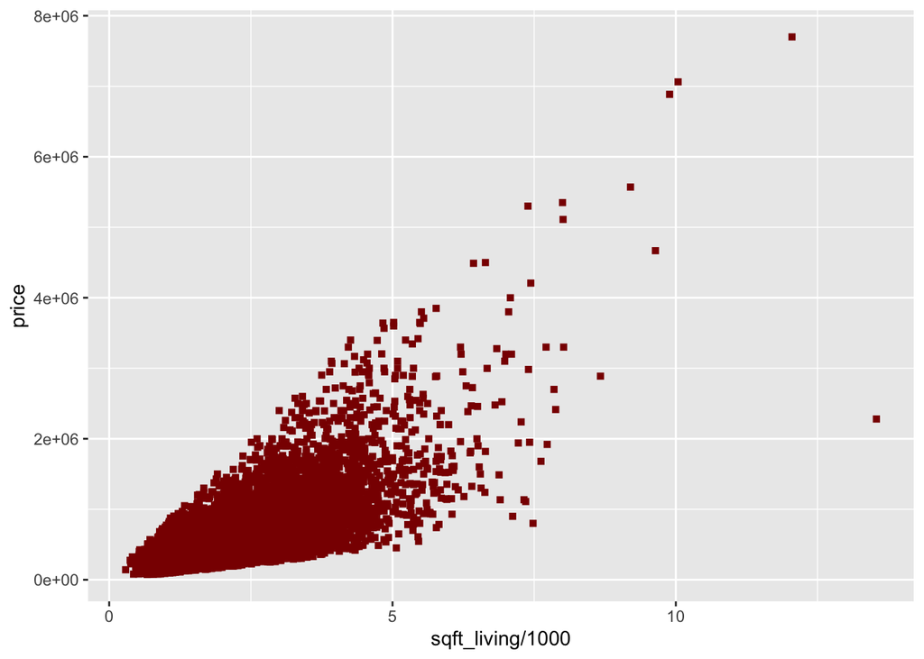

```r
ggplot(house_data, aes(x=sqft_living/1000, y=price)) + geom_point(shape=15,col="darkred")
```

From the aforementioned scatter plot, it becomes evident that the linear relationship between the house price and the square footage of the living area is rather modest. An intriguing observation arises from a solitary outlier, where, despite an exceedingly spacious living area exceeding 10,000 square feet, the price remains confined to the range of $2,000,000 to $3,000,000. Most data points are concentrated within the confines of living areas less than 5,000 square feet, paired with prices below $2,000,000. Conversely, data points become progressively sparse as we venture into the domain of prices surpassing $2,000,000.

To gain further insights, we have undertaken a log transformation of the data to explore the normality assumption. The subsequent scatter plot illustrates this log transformation, revealing a limited linear relationship between the logarithm of the price variable and the square footage of the living area. Nevertheless, it is discernible that as we approach the lower end of the x-axis, a distinctive curvature in the plot becomes apparent. This curvature suggests a non-linear element in the relationship.

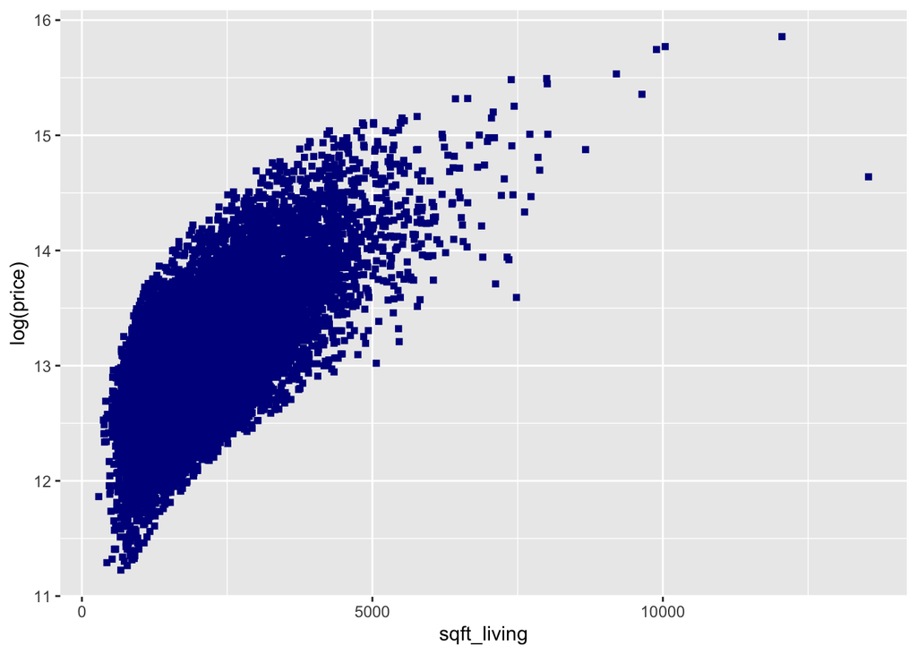

```r
ggplot(house_data, aes(x=sqft_living, y=log(price))) + geom_point(shape=15,col="darkblue")
```

Certainly, to verify the correlation between the two variables, you can compute the Pearson correlation coefficient (Pearson’s r). This coefficient measures the strength and direction of the linear relationship between two continuous variables. In R, you can calculate the correlation as follows:

```r
correlation_coefficient <- cor(log(house_data$price), house_data$sqft_living)
print(correlation_coefficient)
```

```
## [1] 0.6953406
```

The provided code is designed for the purpose of constructing a model, wherein the response variable is the logarithmically transformed price, and the independent variable under consideration is the square footage of the living area, denoted as “sqft_living.” This model is constructed to gain insights into the relationship between the logarithmic representation of house prices and the size of the living area.

```r
fittedlm_log <- lm(log(house_data$price) ~ house_data$sqft_living, data = house_data)
summary(fittedlm_log)
```

```
##
## Call:
## lm(formula = log(house_data$price) ~ house_data$sqft_living,
##     data = house_data)
##
## Residuals:
##      Min       1Q   Median       3Q      Max
## -2.97781 -0.28543  0.01472  0.26070  1.27628
##
## Coefficients:
##                         Estimate Std. Error t value Pr(>|t|)
## (Intercept)            1.222e+01  6.374e-03  1916.9   <2e-16 ***
## house_data$sqft_living 3.987e-04  2.803e-06   142.2   <2e-16 ***
## ---
## Signif. codes:  0 '***' 0.001 '**' 0.01 '*' 0.05 '.' 0.1 ' ' 1
##
## Residual standard error: 0.3785 on 21611 degrees of freedom
## Multiple R-squared:  0.4835, Adjusted R-squared:  0.4835
## F-statistic: 2.023e+04 on 1 and 21611 DF,  p-value: < 2.2e-16
```

Based on the obtained results, it is evident that the intercept is estimated at 1.222e+01, representing the partial coefficient of “sqft_living” on the intercept. The practical significance of this estimate is exceptionally small, with a value of less than 2e-16. This suggests that the intercept is significantly different from zero.

The multiple R-squared value stands at 0.4835, indicating that approximately 48.35% of the variance in the response variable “price” can be explained by the predictor variable “sqft_living.”

However, the adjusted R-squared, which accounts for the model’s degrees of freedom, stands at 48%, suggesting that a considerable portion of the model’s fit remains unexplained. This indicates room for improvement in the model’s predictive capabilities.

The F-statistic, with a value of 2.023e+04, is employed to assess practical significance. A lower p-value associated with the F-statistic signifies the rejection of the null hypothesis, indicating that the intercept is not equal to zero. This further supports the conclusion that the intercept is statistically significant in explaining the variation in the response variable.

The provided code is intended to create a model where the response variable is “price,” and the explanatory variable is “sqft_living.” In this context, you are building a model to explore the relationship between house prices and the square footage of the living area.

```r
fittedlm <- lm(house_data$price ~ house_data$sqft_living, data = house_data)
summary(fittedlm)
```

```
##
## Call:
## lm(formula = house_data$price ~ house_data$sqft_living, data = house_data)
##
## Residuals:
##      Min       1Q   Median       3Q      Max
## -1476062  -147486   -24043   106182  4362067
##
## Coefficients:
##                          Estimate Std. Error t value Pr(>|t|)
## (Intercept)            -43580.743   4402.690  -9.899   <2e-16 ***
## house_data$sqft_living    280.624      1.936 144.920   <2e-16 ***
## ---
## Signif. codes:  0 '***' 0.001 '**' 0.01 '*' 0.05 '.' 0.1 ' ' 1
##
## Residual standard error: 261500 on 21611 degrees of freedom
## Multiple R-squared:  0.4929, Adjusted R-squared:  0.4928
## F-statistic: 2.1e+04 on 1 and 21611 DF,  p-value: < 2.2e-16
```

The multiple R-squared value is computed to be 0.4929, which implies that approximately 49.29% of the variability in the response variable “price” can be accounted for by the predictable variable “sqft_living.”

However, the adjusted R-squared value, at 49%, suggests that the model explains a significant portion of the data, although there is room for further improvement in its explanatory power.

The F-statistic, with a value of 2.1e+04, is used to determine the practical significance of the model. A lower p-value associated with the F-statistic indicates the rejection of the null hypothesis, indicating that the intercept is not equal to zero, reinforcing its statistical significance.

Initially, the model was fitted, and from the fitted model, residuals were extracted. Subsequently, these residuals were plotted to assess their adherence to key assumptions. The purpose was to visually confirm whether the residuals exhibit characteristics that satisfy both the normality assumption and the variance assumptions. This is essential for ensuring the validity of the linear regression model.

To achieve this, normal quantile-quantile (q-q) plots were constructed to assess the normality of the residuals, and studentized residual plots were generated to assess the variance assumptions graphically. These plots are valuable tools for diagnostic checks on the model’s underlying assumptions.

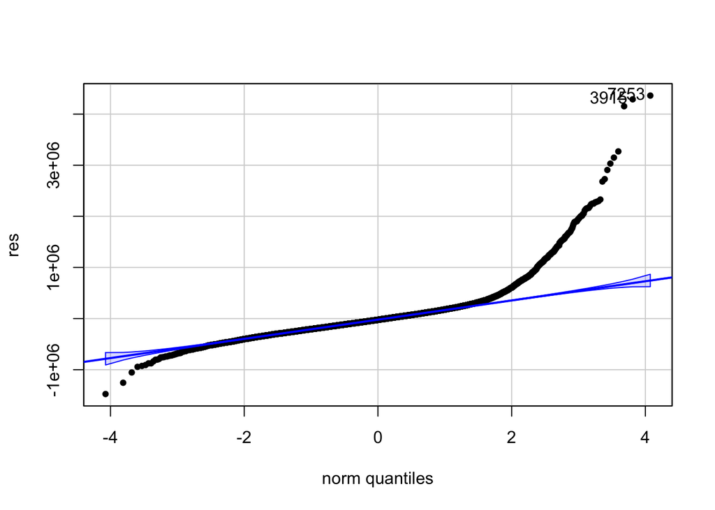

```
## [1] 7253 3915
```

```r
library(e1071)
res <- residuals(fittedlm)

car::qqPlot(res, main = NA, pch = 19, col = 1, cex = 0.7)
```

```r
skew <- skewness(res)
cat("skewness of the residuals -> ", skew)
```

```
## skewness of the residuals ->  2.823452
```

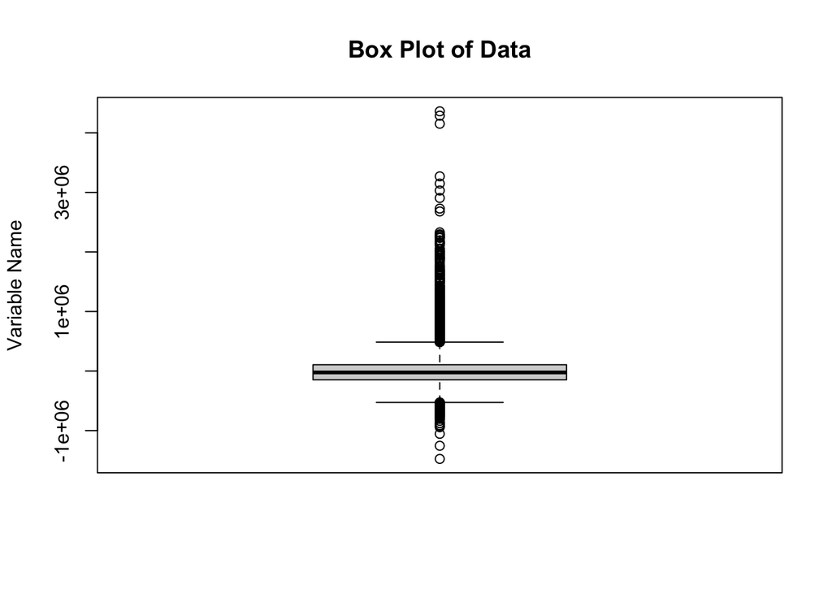

```r
boxplot(res, main = "Box Plot of Data", ylab = "Variable Name")
```

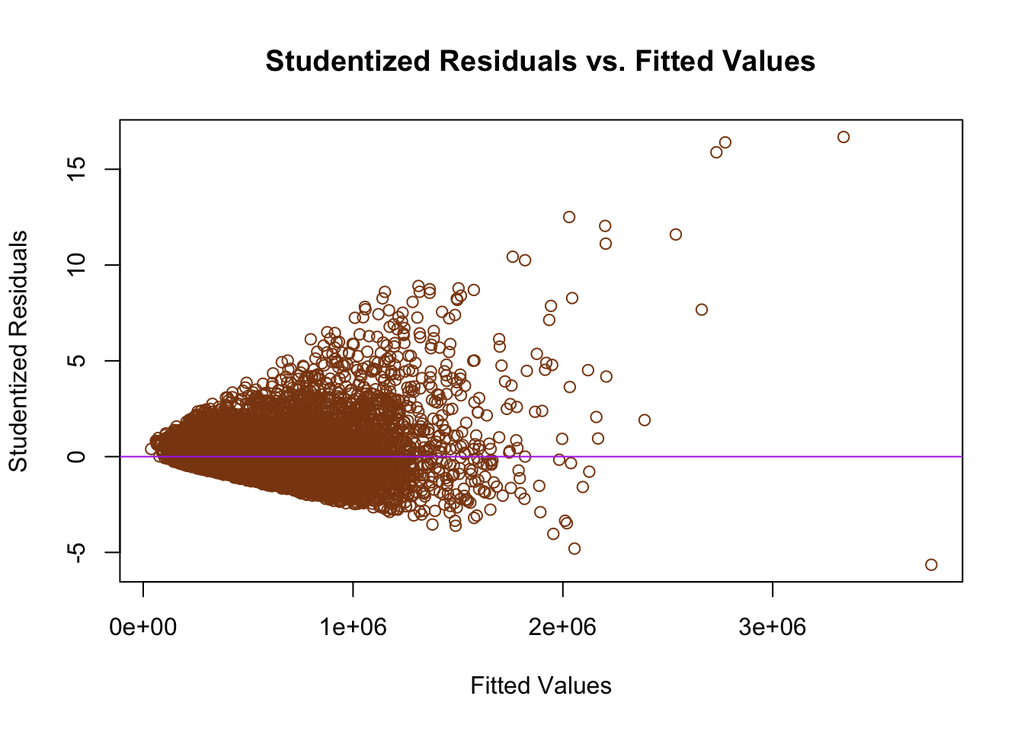

```r
#we need to calcualte the studentised residuals to get the intervals
sigma_residuals <- sigma(fittedlm)
studentized_residuals <- res / sigma_residuals


plot(fitted(fittedlm), studentized_residuals, xlab = "Fitted Values", ylab = "Studentized Residuals",
     main = "Studentized Residuals vs. Fitted Values", col = "chocolate4")
abline(h = 0, col = "darkorchid2")
```

It’s worth noting that performing the Shapiro-Wilk test is not applicable in this case due to the large sample size, as the test is typically limited to sample sizes below 5000. Therefore, when dealing with larger datasets, it is advisable to rely on graphical representations for data interpretation.

Upon examination of the normal quantile-quantile (q-q) plot, it is evident that the data exhibits deviations from the standard reference line. This observation suggests that the data is not following a normal distribution.

Furthermore, the studentized residual vs. fitted values plot provides valuable insights. The majority of data points are within the range of -3 to 3, indicating that the fitted model performs well for most observations. However, it is noteworthy that some outliers exceed this range, signifying potential discrepancies for those specific cases.

In addition, the normal quantile-quantile (q-q) plot for the studentized residuals underscores the departure from the reference line. This deviation from the line indicates that the data does not meet the assumptions of normality and variance. This observation is crucial for assessing the model’s validity and identifying potential areas where further analysis or model refinement may be necessary.

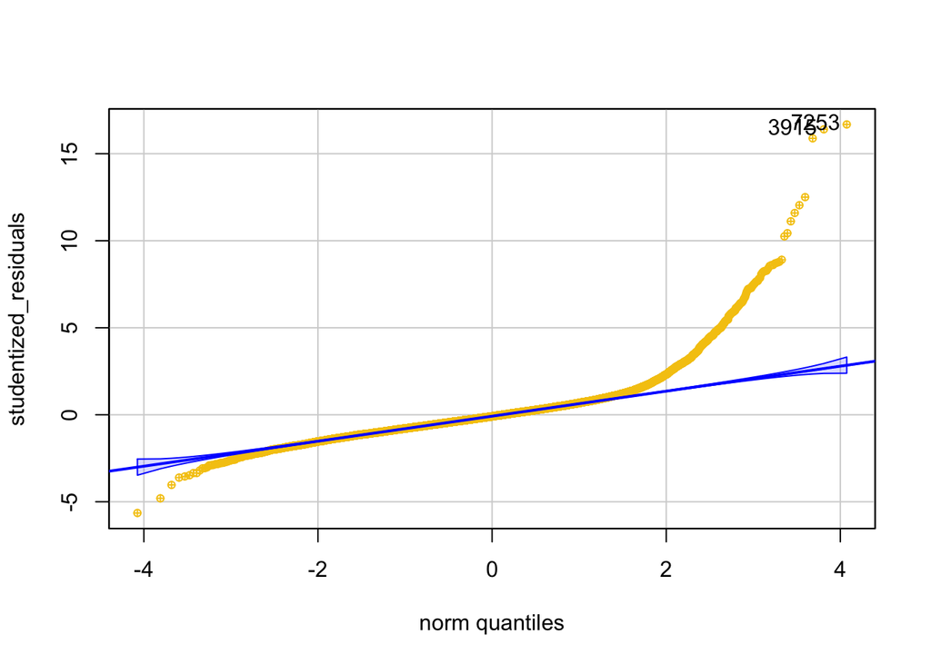

```
## [1] 7253 3915
```

```r
car::qqPlot(studentized_residuals, main = NA, pch = 10, col = 15, cex = 0.7)
```

The following analysis involves working with log-transformed data and the extraction of residuals from it. This process typically includes the following steps:

Log Transformation: The dataset is transformed by taking the natural logarithm (log) of the response variable or other relevant variables. Log transformations are often used to stabilize variance and make the data more suitable for linear modeling.

Model Fitting: After log transformation, a regression model or other statistical model is fitted to the transformed data. This model aims to capture the relationship between the transformed response variable and predictor variables.

Residual Extraction: Residuals are obtained by subtracting the model’s predicted values from the observed values. Residuals represent the differences between the actual data and the data predicted by the model.

Residual Analysis: The residuals are then subjected to various diagnostic tests and visualizations to assess the model’s fit and the validity of underlying assumptions. This includes checks for normality, homoscedasticity, and potential outliers.

The use of log transformations is common in statistical analysis, particularly when dealing with data that does not meet the assumptions of linear regression or other statistical models. Log transformations can help stabilize the variance and make the relationships between variables more linear and interpretable.

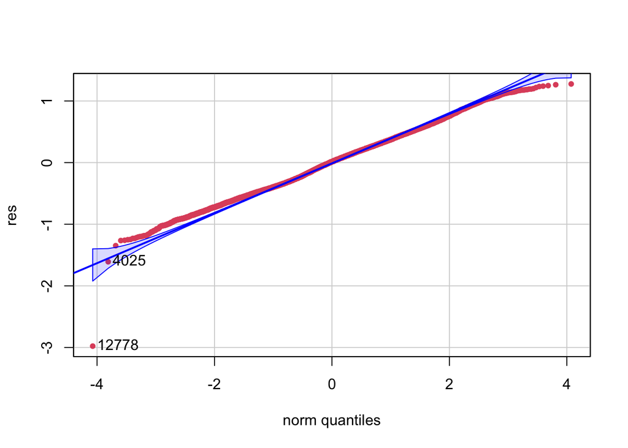

```
## [1] 12778  4025
```

```r
#log trasnformed data
library(e1071)
res <- residuals(fittedlm_log)

car::qqPlot(res, main = NA, pch = 19, col = 2, cex = 0.7)
```

```r
skew <- skewness(res)
cat("skewness of the residuals -> ", skew)
```

```
## skewness of the residuals ->  0.02661918
```

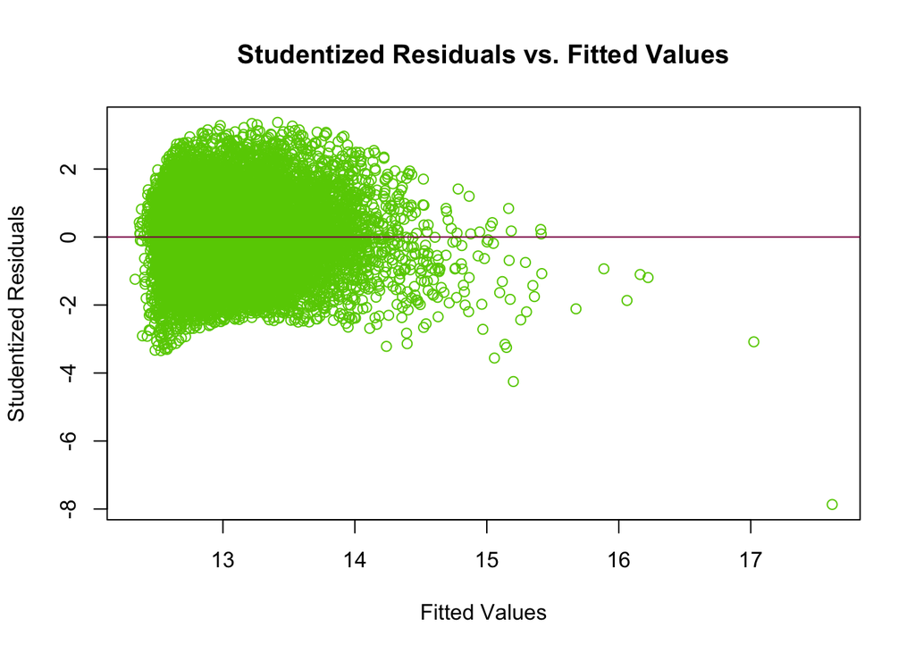

```r
#we need to calcualte the studentised residuals to get the intervals
sigma_residuals <- sigma(fittedlm_log)
studentized_residuals <- res / sigma_residuals

plot(fitted(fittedlm_log), studentized_residuals, xlab = "Fitted Values", ylab = "Studentized Residuals",
     main = "Studentized Residuals vs. Fitted Values", col = "chartreuse3")
abline(h = 0, col = "deeppink4")
```

Furthermore, the studentized residual vs. fitted values plot reveals an important aspect of the model’s performance. Most of the data points cluster within the range of -2 to 2, implying that the fitted model generally provides a good fit for the majority of observations. However, it’s noteworthy that some outliers fall outside this range, indicating potential discrepancies or unusual cases.

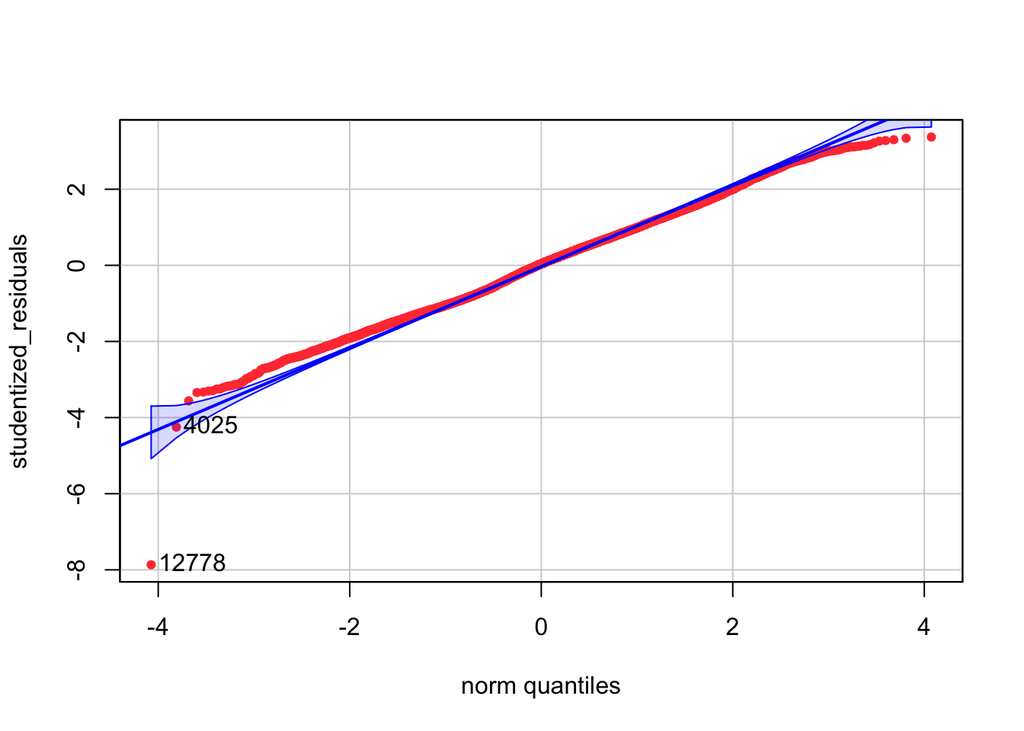

```
## [1] 12778  4025
```

```r
car::qqPlot(studentized_residuals, main = NA, pch = 19, col = "brown1", cex = 0.7)
```

The presented chart is intended to fit a model using log-transformed data for the purpose of identifying outliers within the model. This process involves transforming the data, building a model, and subsequently detecting any data points that deviate significantly from the model’s predictions. Outliers, if present, can be crucial to understand as they may influence the model’s performance and insights drawn from the data.

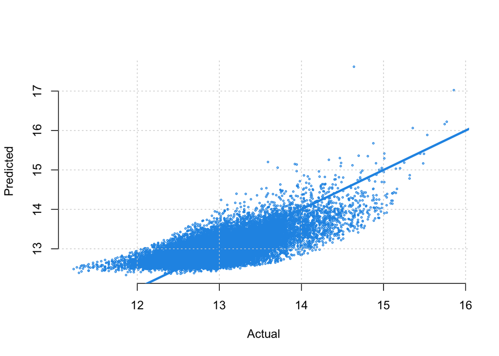

```r
plot(log(house_data$price), predict(fittedlm_log,newdata = house_data),
     col=4, cex=0.3, xlab="Actual", ylab="Predicted", axes=FALSE)

extpts <- which(abs(residuals(fittedlm_log)) > 3*sd(residuals(fittedlm_log)))
text(house_data$price[extpts],
     predict(fittedlm_log, newdata = house_data)[extpts],
     rownames(house_data$price)[extpts], cex=0.5, col=2)
axis(1); axis(2); grid(); abline(0,1, col=4, lwd=3)
```

The provided code is designed to identify and extract outliers from the dataset based on the residuals of a statistical model. Specifically, it identifies data points for which the residuals are greater than three times the standard deviation of the model.

Once these outliers are identified, they are removed from the dataset, creating a new data frame with the outliers excluded. Subsequently, a new model is fitted to this filtered dataset. This process allows for the creation of a model that is less influenced by extreme or influential data points, potentially leading to a more robust and accurate model.

```r
house_data.2 <- house_data[-extpts,]
mod.2 <- lm(log(price) ~ sqft_living, data = house_data.2)
summary(mod.2)
```

```
##
## Call:
## lm(formula = log(price) ~ sqft_living, data = house_data.2)
##
## Residuals:
##      Min       1Q   Median       3Q      Max
## -1.12266 -0.28462  0.01431  0.26038  1.13015
##
## Coefficients:
##              Estimate Std. Error t value Pr(>|t|)
## (Intercept) 1.221e+01  6.351e-03  1923.0   <2e-16 ***
## sqft_living 4.010e-04  2.800e-06   143.2   <2e-16 ***
## ---
## Signif. codes:  0 '***' 0.001 '**' 0.01 '*' 0.05 '.' 0.1 ' ' 1
##
## Residual standard error: 0.3739 on 21559 degrees of freedom
## Multiple R-squared:  0.4875, Adjusted R-squared:  0.4875
## F-statistic: 2.051e+04 on 1 and 21559 DF,  p-value: < 2.2e-16
```

The multiple R-squared value is computed at 0.4875, indicating that approximately 48.75% of the variance in the response variable “price” can be explained by the predictable variable “sqft_living.”

However, the adjusted R-squared value, at 48.75%, suggests that the model accounts for a significant proportion of the data’s variability. Yet, it’s important to note that there is room for improvement in the model’s explanatory power.

The F-statistic, with a value of 2.051e+04, is used to assess practical significance. A lower p-value associated with the F-statistic indicates the rejection of the null hypothesis, confirming that the intercept is not equal to zero. This underscores the statistical significance of the intercept in explaining the variation in the response variable.

It’s noteworthy that there is a minor increase of 0.0040 in the multiple R-squared value between the models, indicating a marginal enhancement in the model’s performance. While the improvement is not substantial, it suggests that the refined model is slightly better at explaining the variability in the response variable.

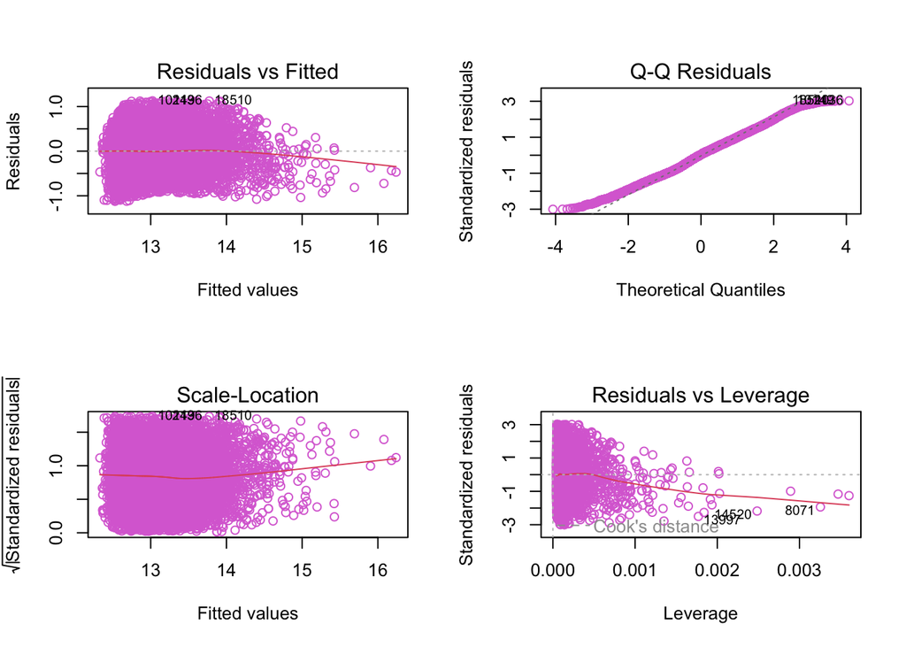

```r
par(mfrow=c(2,2))
plot(mod.2, col = "orchid")
```

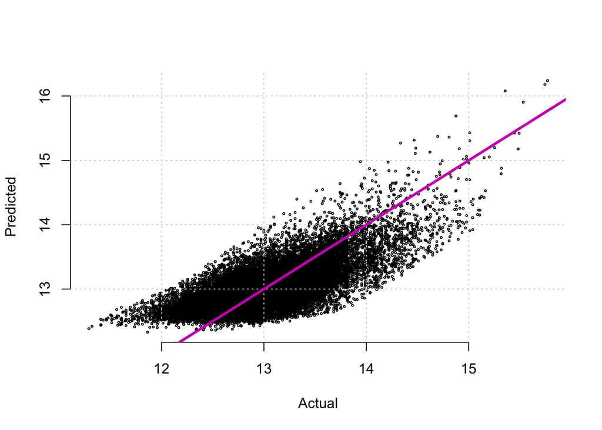

```r
plot(log(house_data.2$price), predict(mod.2,newdata = house_data.2),
     col=09, cex=0.3, xlab="Actual", ylab="Predicted", axes=FALSE)
axis(1); axis(2); grid(); abline(0,1, col=6, lwd=3)
```

From the above chart we can view there are no outliers and are eliminated.

```r
fittedlm_log <- lm(log(house_data$price) ~ house_data$sqft_living, data = house_data)
summary(fittedlm_log)
```

```
##
## Call:
## lm(formula = log(house_data$price) ~ house_data$sqft_living,
##     data = house_data)
##
## Residuals:
##      Min       1Q   Median       3Q      Max
## -2.97781 -0.28543  0.01472  0.26070  1.27628
##
## Coefficients:
##                         Estimate Std. Error t value Pr(>|t|)
## (Intercept)            1.222e+01  6.374e-03  1916.9   <2e-16 ***
## house_data$sqft_living 3.987e-04  2.803e-06   142.2   <2e-16 ***
## ---
## Signif. codes:  0 '***' 0.001 '**' 0.01 '*' 0.05 '.' 0.1 ' ' 1
##
## Residual standard error: 0.3785 on 21611 degrees of freedom
## Multiple R-squared:  0.4835, Adjusted R-squared:  0.4835
## F-statistic: 2.023e+04 on 1 and 21611 DF,  p-value: < 2.2e-16
```

Based on the summary provided, it is evident that for the intercept, both the null and alternate hypotheses are evaluated using a t-test. The null hypothesis typically states that the coefficient is equal to 0, while the alternate hypothesis suggests that it is not equal to 0.

In this case, the null hypothesis for the intercept is rejected since the p-value is less than 0.05, indicating statistical significance. The same conclusion applies to the alternate hypothesis, which suggests that the intercept is indeed not equal to 0.

```r
coef_names <- names(coef(fittedlm_log))
confint(fittedlm_log)["(Intercept)", ]
```

```
##    2.5 %   97.5 %
## 12.20597 12.23096
```

```r
confint(fittedlm_log)["house_data$sqft_living", ]
```

```
##        2.5 %       97.5 %
## 0.0003932515 0.0004042416
```

The provided code is dedicated to predicting house prices based on the square footage of the living area (sqft_living). The process involves converting the relevant values into a data frame and then applying the exponential function to the predicted values generated from the previously fitted statistical model.

In essence, this code calculates price predictions using the model, and the exponential transformation is applied to these predictions to obtain meaningful price values, which were originally log-transformed during the modeling process. This allows for the presentation of price estimates in their original, interpretable form.

```r
new_data <- data.frame(sqft_living = c(1500))

# Predict the response variable based on the new data
predicted_price <- exp(predict(mod.2, newdata = new_data,  interval = "confidence", level = 0.95))
predicted_price
```

```
##      fit      lwr      upr
## 1 367676 365508.4 369856.5
```

In conclusion, based on the modeling and prediction process, it is estimated that a house with 1,500 square feet of living area is predicted to have a price of approximately $367,676. This prediction provides valuable insights into the expected price of such a property given its living area size.